# NLP for Social Scientists

Week 1 — Concepts, Use Cases & First Steps in R

Author

Bence Ságvári · Corvinus University of Budapest

Published

Invalid Date

# 1 What Is Text as Data?

Language surrounds social life. Politicians speak in manifestos and inaugural addresses. Citizens express themselves in open-ended survey responses. Courts write decisions; newspapers frame events; social media users argue about everything. Yet for most of social science’s history, text could only be studied by reading it — slowly, manually, one document at a time.

NLP changes the terms of that bargain. A human researcher can read perhaps 10–20 documents per hour. A computer can process 10,000. This is not merely a speed difference; it is a difference in what questions become answerable.

Text-as-data approaches let us apply social science concepts — framing, sentiment, ideology, identity — to corpora that would be impossible to read in full:

- All parliamentary speeches since 1950
- Every newspaper front page over a decade
- Millions of social media posts
- Tens of thousands of open-ended survey responses

The core move is straightforward: we treat language as **structured, countable, comparable material**. Words become variables. Documents become observations. A corpus becomes a dataset.

## 1.1 Types of Text in Social Science

Text enters social science research in many forms:

| Type | Examples |
| --- | --- |
| **Political** | Speeches, manifestos, parliamentary debates, party platforms |
| **Media** | News articles, editorials, social media, transcribed podcasts |
| **Administrative** | Court decisions, policy documents, bureaucratic records |
| **Survey** | Open-ended responses, interview transcripts, focus groups |
| **Historical** | Archives, digitised newspapers, diaries, letters |

Each type brings its own preprocessing challenges, its own vocabulary biases, and its own implicit assumptions about what counts as a meaningful unit of analysis. Keeping track of these differences is as important as the method itself.

# 2 The Method Ladder

NLP methods vary enormously in complexity and in what they assume about language. It helps to think of them as a ladder: each rung answers a different kind of question, and each rung requires more interpretive judgement than the one below it.

| Step | Method | Research Question |
| --- | --- | --- |
| **1** | Frequency & Keywords | What words are most distinctive of this corpus or group? |
| **2** | Dictionary & Sentiment | How much negativity / populism / emotion is in these texts? |
| **3** | Topic Modelling | What themes run through this corpus, and how do they vary? |
| **4** | Supervised Classification | Does this document express support or opposition to X? |
| **5** | Embeddings & Language Models | Which documents are semantically closest to this concept? |

This course works through the first four rungs over four weeks. Today covers Step 1 — frequency and keywords — using real political speech data. The key principle to hold onto: **complexity increases, and so does the interpretive effort required**.

## 2.1 Four Published Use Cases

Before writing a single line of code, it is worth anchoring these methods in actual published work. Each example below uses a different method family and illustrates what scale makes possible.

**Ideological scaling of manifestos.** Laver, Benoit & Garry (2003) estimated party positions from election manifestos by treating word frequencies as ideological signals — no human coding required. They reproduced results from expensive expert surveys at a fraction of the cost and time.

**Sentiment in parliamentary debates.** Researchers tracked the emotional tone of parliamentary speeches over decades, finding that negative sentiment spikes during economic crises and correlates with populist voting. This connects macro-political events to the actual language of democratic institutions.

**Media framing of migration.** Heidenreich et al. (2019) used structural topic models to show that migration coverage in European newspapers frames the issue as a ‘threat’ significantly more often in right-wing outlets — across 1.3 million articles in 7 countries, a scale impossible by hand.

**Scaling up survey open-responses.** Researchers trained a classifier on a human-coded subset of open-ended responses, then applied it to the remaining 40,000 — reproducing the manual coding scheme at scale with over 85% accuracy. This bridges qualitative insight and quantitative scale.

# 3 The Measurement Problem

Before touching any data, we need to sit with what is arguably the most important conceptual issue in this course.

NLP tools produce **outputs** — sentiment scores, topic proportions, word frequencies, classifier labels. But what social scientists care about are **constructs** — attitudes, social phenomena, meanings, behaviours. These are not the same thing, and the gap between them is where most analytical mistakes are made.

```
NLP output             ≠          Your construct
─────────────────────────────────────────────────
Sentiment score        ≠          Attitude
Topic proportion       ≠          Social phenomenon
Word frequency         ≠          Meaning
Classifier label       ≠          Behaviour
```

Every NLP measure needs a **validity argument**. Ask yourself: does this operationalisation actually capture the concept I care about — in this language, this domain, this time period? A sentiment lexicon trained on English product reviews will not travel cleanly to 19th-century inaugural rhetoric. A topic model with 20 topics will tell you something different from one with 5.

This is not a reason to avoid NLP. It is a reason to be explicit and honest about what your measures are doing — exactly as you would be with any survey scale or observational measure.

# 4 Limits and Honest Expectations

NLP is a powerful tool, not a shortcut. Here are five limitations worth taking seriously from the start.

**Language and domain dependency.** Models trained on contemporary social media perform poorly on formal political speech from the 18th century. Pre-trained models embed the cultural assumptions of their training corpora. Always validate on your specific data.

**Cleaning takes longer than analysis.** OCR errors, encoding issues, inconsistent formatting, domain-specific stopwords — text data is rarely clean. Expect 60–70% of project time to be preprocessing, not modelling.

**Black boxes and reproducibility.** Large language models are difficult to interpret. Results can change with model versions. Always report the model, version, hyperparameters, and preprocessing decisions.

**Quantity ≠ quality.** A million documents does not guarantee valid inference. Biased corpora, missing voices, and survivorship bias are real threats to external validity.

**NLP is a tool, not a theory.** The research question, the theoretical framework, and the interpretation must still come from you. NLP operationalises concepts — it does not generate them.

# 5 The Corpus: US Presidential Inaugural Addresses

For the coding sections of this course we use the **US Presidential Inaugural Address corpus**, which ships directly with the `quanteda` package — no additional installation required. This corpus is widely used in computational political science teaching and research.

## 5.1 What the Corpus Contains

| Variable | Description |
| --- | --- |
| `President` | President’s surname |
| `FirstName` | President’s first name |
| `Year` | Year of the address |
| `Party` | President’s party affiliation |

```r
# Load the corpus — ships with base quanteda, no extra install needed
corp <- data_corpus_inaugural

# Quick overview
summary(corp, n = 8)
```

|  | Text | Types | Tokens | Sentences | Year | President | FirstName | Party |
| --- | --- | --- | --- | --- | --- | --- | --- | --- |
| 1 | 1789-Washington | 625 | 1537 | 24 | 1789 | Washington | George | none |
| 2 | 1793-Washington | 96 | 147 | 5 | 1793 | Washington | George | none |
| 3 | 1797-Adams | 826 | 2577 | 37 | 1797 | Adams | John | Federalist |
| 4 | 1801-Jefferson | 717 | 1923 | 43 | 1801 | Jefferson | Thomas | Democratic-Republican |
| 5 | 1805-Jefferson | 804 | 2380 | 45 | 1805 | Jefferson | Thomas | Democratic-Republican |
| 6 | 1809-Madison | 535 | 1261 | 21 | 1809 | Madison | James | Democratic-Republican |
| 7 | 1813-Madison | 541 | 1302 | 33 | 1813 | Madison | James | Democratic-Republican |
| 8 | 1817-Monroe | 1040 | 3677 | 121 | 1817 | Monroe | James | Democratic-Republican |

The summary shows each address with its token count and docvars. Speeches vary enormously in length — Washington’s second inaugural was just 135 words; William Henry Harrison’s 1841 address ran to over 8,000. This variation is itself sociologically informative: the norms of presidential communication have shifted dramatically over two centuries.

```r
# How many addresses per party?
docvars(corp) |>
  count(Party, sort = TRUE)
```

| Party | n |
| --- | --- |
| Republican | 25 |
| Democratic | 22 |
| Democratic-Republican | 7 |
| Whig | 3 |
| none | 2 |
| Federalist | 1 |

```r
# Distribution over time
docvars(corp) |>
  count(Party) |>
  arrange(desc(n))
```

| Party | n |
| --- | --- |
| Republican | 25 |
| Democratic | 22 |
| Democratic-Republican | 7 |
| Whig | 3 |
| none | 2 |
| Federalist | 1 |

The corpus spans the full arc of American political history: Federalists and Democratic-Republicans in the early republic, Democrats and Whigs in the antebellum era, and the familiar Democrat/Republican split from the Civil War onwards. This long time span makes tf-idf particularly powerful — we can track which concerns defined each era’s political language.

## 5.2 Grouping Speeches into Eras

```r
# Add an era variable to the corpus docvars
corp <- corp |>
  corpus_subset(select = TRUE)   # keep all documents

docvars(corp, "era") <- case_when(
  docvars(corp, "Year") < 1829 ~ "Founding Era (1789–1828)",
  docvars(corp, "Year") < 1865 ~ "Antebellum (1829–1864)",
  docvars(corp, "Year") < 1933 ~ "Industrial Age (1865–1932)",
  docvars(corp, "Year") < 1981 ~ "New Deal & Cold War (1933–1980)",
  TRUE                          ~ "Contemporary (1981–2021)"
)

# Confirm
docvars(corp) |>
  count(era)
```

| era | n |
| --- | --- |
| Antebellum (1829–1864) | 9 |
| Contemporary (1981–2021) | 12 |
| Founding Era (1789–1828) | 10 |
| Industrial Age (1865–1932) | 17 |
| New Deal & Cold War (1933–1980) | 12 |

# 6 The tidytext Framework

We now turn to code. This section introduces the `tidytext` package (Silge & Robinson 2017), which brings text analysis into the tidyverse ecosystem.

## 6.1 The Tidy Text Principle

The fundamental idea is simple: **one token per row**. A *token* is a meaningful unit of text — usually a word — and *tokenisation* is the process of splitting text into tokens. Structuring data this way makes it immediately compatible with `dplyr`, `ggplot2`, and the rest of the tidyverse.

Consider the contrast:

**Raw format** — one document per row, text as a single string:

```
doc_id          Year  Party  text
Washington-1789 1789  none   'Fellow citizens, I am again called...'
Adams-1797      1797  Federalist  'When it was first perceived...'
```

**Tidy text format** — one token per row:

```
doc_id          Year  Party  word
Washington-1789 1789  none   fellow
Washington-1789 1789  none   citizens
Adams-1797      1797  Federalist  perceived
```

The transformation between these two representations is handled by a single function: `unnest_tokens()`.

## 6.2 Converting the Corpus to a Tidy Data Frame

We convert the `quanteda` corpus object to a plain data frame, then tokenise:

```r
# Convert corpus to tidy data frame — one row per speech
inaugural_df <- corp |>
  convert(to = "data.frame") |>
  as_tibble() |>
  rename(text = text)

glimpse(inaugural_df)
```

```
Rows: 60
Columns: 7
$ doc_id    <chr> "1789-Washington", "1793-Washington", "1797-Adams", "1801-Je…
$ text      <chr> "Fellow-Citizens of the Senate and of the House of Represent…
$ Year      <int> 1789, 1793, 1797, 1801, 1805, 1809, 1813, 1817, 1821, 1825, …
$ President <chr> "Washington", "Washington", "Adams", "Jefferson", "Jefferson…
$ FirstName <chr> "George", "George", "John", "Thomas", "Thomas", "James", "Ja…
$ Party     <fct> none, none, Federalist, Democratic-Republican, Democratic-Re…
$ era       <chr> "Founding Era (1789–1828)", "Founding Era (1789–1828)", "Fou…
```

```r
# Tokenise with unnest_tokens() — one word per row
tidy_inaugural <- inaugural_df |>
  unnest_tokens(word, text)

cat("Total tokens:", nrow(tidy_inaugural), "\n")
```

```
Total tokens: 140857
```

## 6.3 Removing Stop Words

Most of the most frequent words in any text are grammatical function words: *the*, *and*, *of*, *to*. These carry no discriminating information for most research questions and are typically removed. The `tidytext` package ships a stop word list drawn from multiple lexicons:

```r
data(stop_words)

tidy_inaugural <- tidy_inaugural |>
  anti_join(stop_words, by = "word") |>
  filter(str_detect(word, "^[a-z]"))   # drop stray numbers and symbols

cat("Tokens after stop word removal:", nrow(tidy_inaugural), "\n")
```

```
Tokens after stop word removal: 51964
```

The `anti_join()` keeps only rows whose `word` value does *not* appear in `stop_words`. The additional `filter()` removes numeric tokens that survive stop word removal but carry no interpretable lexical content.

## 6.4 The Most Frequent Words Overall

[output not shown]

[output cut: 293 more lines]

[output not shown]

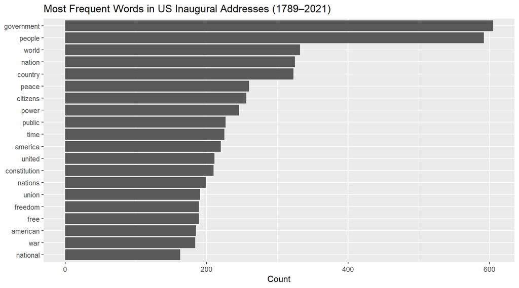

Figure 1: The 20 most frequent content words across all US inaugural addresses (1789–2021), after stop word removal.

```r
tidy_inaugural |>
  count(word, sort = TRUE) |>
  slice_head(n = 20) |>
  mutate(word = reorder(word, n)) |>
  ggplot(aes(x = word, y = n)) +
  geom_col()+ #fill = "#1B6CA8") +
  coord_flip() +
  labs(
    title = "Most Frequent Words in US Inaugural Addresses (1789–2021)",
    x = NULL,
    y = "Count"
  ) #+
  ggthemes::theme_fivethirtyeight(base_size = 20)
```

The top words — “government”, “people”, “nation”, “world”, “peace”, “freedom” — are the perennial vocabulary of American political identity. This is again a validating result: these are exactly the abstractions one expects in ceremonial political speech. Their universality across all presidents is also a reminder of why raw frequency alone is insufficient — to find what is *distinctive* about any era or president, we need tf-idf.

## 6.5 Word Frequencies by Party

Before moving to tf-idf, a simpler comparison: how does the vocabulary of Democratic versus Republican presidents differ in proportional terms?

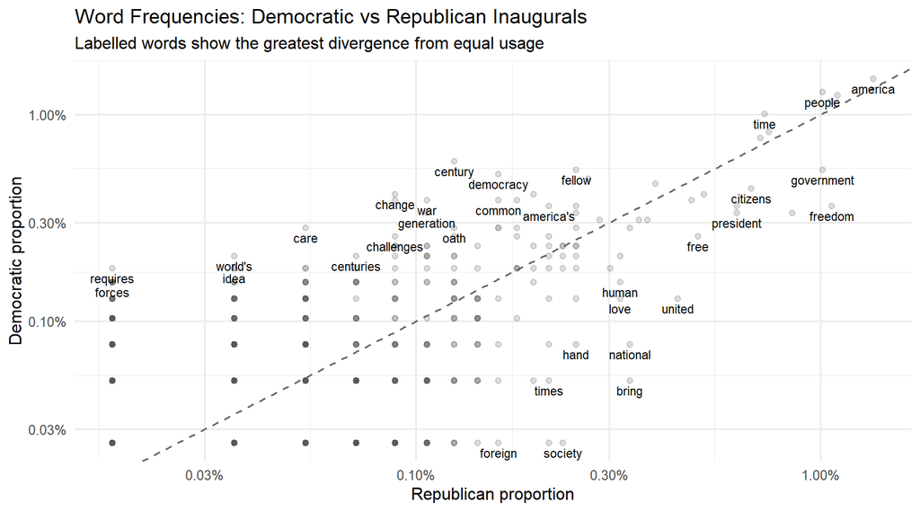

```r
tidy_inaugural_recent <- tidy_inaugural |>
  filter(era == "Contemporary (1981–2021)")

party_freq <- tidy_inaugural_recent |>
  filter(Party %in% c("Democratic", "Republican")) |>
  count(Party, word) |>
  group_by(Party) |>
  mutate(proportion = n / sum(n)) |>
  select(-n) |>
  pivot_wider(names_from = Party, values_from = proportion) |>
  drop_na()

# Label the most divergent words
divergent <- party_freq |>
  mutate(diff = abs(Democratic - Republican)) |>
  slice_max(diff, n = 50)

ggplot(party_freq, aes(x = Republican, y = Democratic)) +
  geom_abline(colour = "gray40", linetype = 2) +
  geom_point(alpha = .2, size = 1.8, colour = "#555555") +
  geom_text(
    data = divergent,
    aes(label = word),
    check_overlap = TRUE, size = 3, vjust = 1.5
  ) +
  scale_x_log10(labels = percent_format(accuracy = 0.01)) +
  scale_y_log10(labels = percent_format(accuracy = 0.01)) +
  labs(
    title = "Word Frequencies: Democratic vs Republican Inaugurals",
    subtitle = "Labelled words show the greatest divergence from equal usage",
    x = "Republican proportion",
    y = "Democratic proportion"
  ) +
  theme_minimal(base_size = 12)
```

# 7 tf-idf: Measuring Distinctiveness

Raw frequency tells us what words are common. But if a word appears in every inaugural address — “government”, “people”, “nation” — its frequency tells us nothing about what makes any particular era or president distinctive. What we want is a measure of *distinctiveness*: words that are frequent in one group’s speeches but rare across the corpus as a whole.

This is what **tf-idf** (term frequency–inverse document frequency) measures.

$$\text{tf-idf}(t, d, D) = \underbrace{\frac{f_{t,d}}{\sum_{t'} f_{t',d}}}_{\text{term frequency}} \times \underbrace{\log \frac{|D|}{|\{d \in D : t \in d\}|}}_{\text{inverse document frequency}}$$

A word scores high on tf-idf when it is frequent within a document *and* rare across other documents. Universal words like “nation” score near zero because they appear everywhere (their IDF approaches zero). A word specific to one era — a proper name, a policy term, a historically-situated concept — scores high because it is used in that group but largely absent from others.

## 7.1 tf-idf by Era

We compute tf-idf with each era treated as a single aggregated document:

```r
inaugural_tfidf <- tidy_inaugural |>
  count(era, word, sort = TRUE) |>
  bind_tf_idf(word, era, n) |>
  arrange(desc(tf_idf))

writexl::write_xlsx(inaugural_tfidf, "inaugural_tfidf.xls")

inaugural_tfidf |>
  select(era, word,  n, tf, idf, tf_idf) |>
  slice_head(n = 100)
```

| era | word | n | tf | idf | tf_idf |
| --- | --- | --- | --- | --- | --- |
| Contemporary (1981–2021) | americans | 74 | 0.0077804647 | 0.5108256 | 0.0039744607 |
| Contemporary (1981–2021) | america's | 26 | 0.0027336768 | 0.9162907 | 0.0025048427 |
| Contemporary (1981–2021) | jobs | 14 | 0.0014719798 | 1.6094379 | 0.0023690601 |
| Contemporary (1981–2021) | story | 21 | 0.0022079697 | 0.9162907 | 0.0020231422 |
| New Deal & Cold War (1933–1980) | peoples | 26 | 0.0035684875 | 0.5108256 | 0.0018228749 |
| Antebellum (1829–1864) | texas | 11 | 0.0009891197 | 1.6094379 | 0.0015919267 |
| Contemporary (1981–2021) | workers | 9 | 0.0009462727 | 1.6094379 | 0.0015229672 |
| Antebellum (1829–1864) | confederacy | 18 | 0.0016185595 | 0.9162907 | 0.0014830711 |
| Contemporary (1981–2021) | challenges | 15 | 0.0015771212 | 0.9162907 | 0.0014451016 |
| Contemporary (1981–2021) | families | 15 | 0.0015771212 | 0.9162907 | 0.0014451016 |

[output cut: 90 more lines]

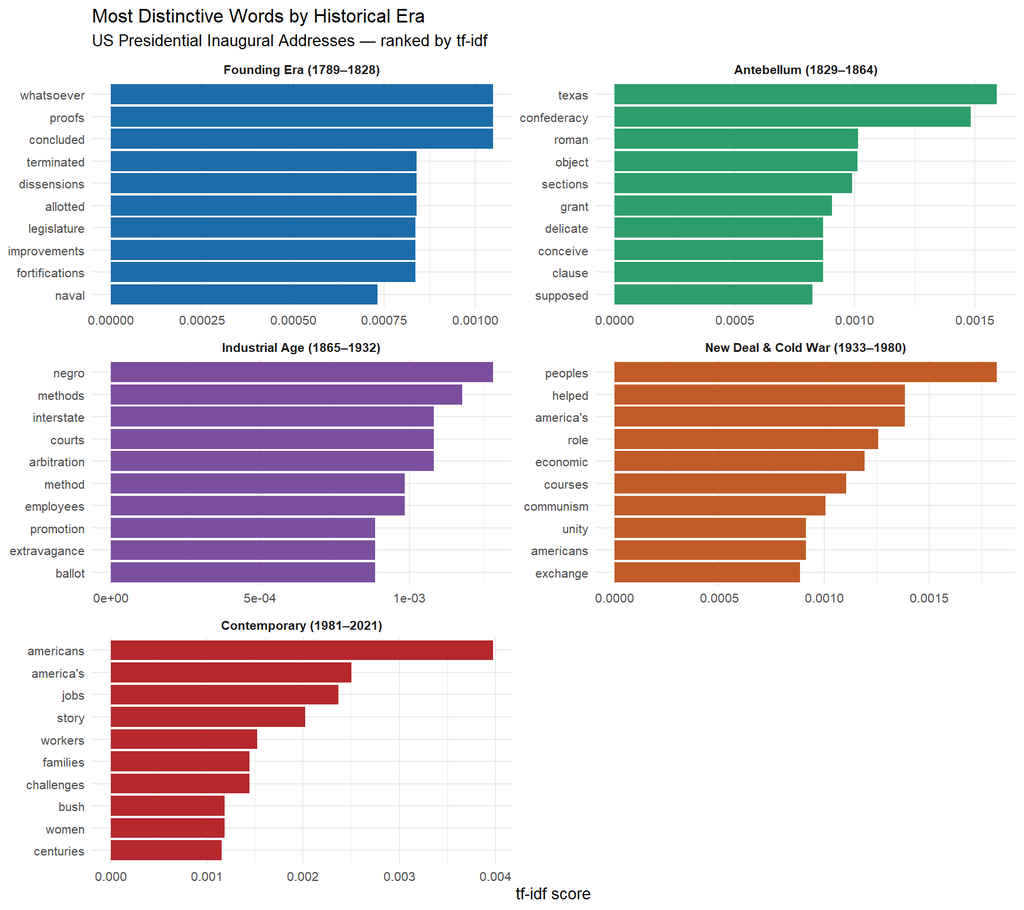

Figure 3: Most distinctive words per historical era in US inaugural addresses, ranked by tf-idf score.

```r
inaugural_tfidf |>
  group_by(era) |>
  slice_max(tf_idf, n = 10) |>
  ungroup() |>
  mutate(
    word = reorder_within(word, tf_idf, era),
    era  = factor(era, levels = c(
      "Founding Era (1789–1828)",
      "Antebellum (1829–1864)",
      "Industrial Age (1865–1932)",
      "New Deal & Cold War (1933–1980)",
      "Contemporary (1981–2021)"
    ))
  ) |>
  ggplot(aes(x = word, y = tf_idf, fill = era)) +
  geom_col(show.legend = FALSE) +
  facet_wrap(~era, scales = "free", ncol = 2) +
  coord_flip() +
  scale_x_reordered() +
  scale_fill_manual(values = c(
    "Founding Era (1789–1828)"        = "#1B6CA8",
    "Antebellum (1829–1864)"          = "#2D9E6B",
    "Industrial Age (1865–1932)"      = "#7B4F9E",
    "New Deal & Cold War (1933–1980)" = "#C05B28",
    "Contemporary (1981–2021)"        = "#B5282C"
  )) +
  labs(
    title = "Most Distinctive Words by Historical Era",
    subtitle = "US Presidential Inaugural Addresses — ranked by tf-idf",
    x = NULL,
    y = "tf-idf score"
  ) +
  theme_minimal(base_size = 10) +
  theme(strip.text = element_text(face = "bold"))
```

Each era’s distinctive words are not simply the most frequent words — they are what sets that era apart. tf-idf has extracted a compressed political history of the United States from word counts alone. The social scientist’s job is to ask whether that extraction is *valid*: does distinctive vocabulary actually reflect distinctive political concerns, or are some differences artefacts of changing speech norms, address length, or ghostwriting?

## 7.2 tf-idf by Individual President

We can apply the same logic at the level of individual presidents, which reveals idiosyncratic rhetorical signatures:

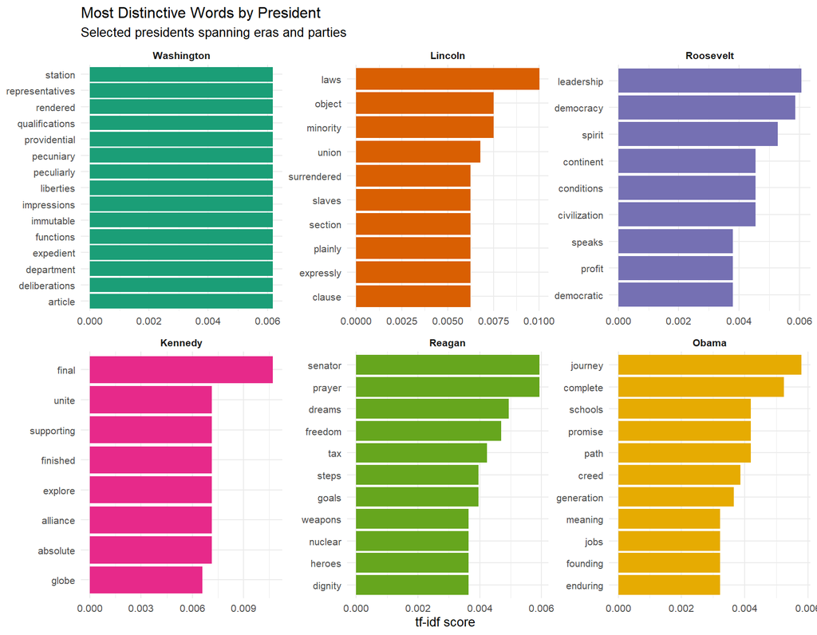

Figure 4: Most distinctive words for six selected presidents, ranked by tf-idf. Presidents are chosen to span eras and parties.

```r
# Select a representative set of presidents across eras and parties
selected <- c("Washington", "Lincoln", "Roosevelt", "Kennedy", "Reagan", "Obama")

tidy_inaugural |>
  filter(President %in% selected) |>
  count(President, word, sort = TRUE) |>
  bind_tf_idf(word, President, n) |>
  group_by(President) |>
  slice_max(tf_idf, n = 8) |>
  ungroup() |>
  mutate(
    word      = reorder_within(word, tf_idf, President),
    President = factor(President, levels = selected)
  ) |>
  ggplot(aes(x = word, y = tf_idf, fill = President)) +
  geom_col(show.legend = FALSE) +
  facet_wrap(~President, scales = "free", ncol = 3) +
  coord_flip() +
  scale_x_reordered() +
  scale_fill_brewer(palette = "Dark2") +
  labs(
    title = "Most Distinctive Words by President",
    subtitle = "Selected presidents spanning eras and parties",
    x = NULL,
    y = "tf-idf score"
  ) +
  theme_minimal(base_size = 10) +
  theme(strip.text = element_text(face = "bold"))
```

At the individual level, tf-idf surfaces both historical context and rhetorical style. Lincoln’s distinctive vocabulary reflects the Civil War crisis; Kennedy’s the Cold War and the space age; Reagan’s the conservative turn and Cold War confrontation. These are not just historical curiosities — they illustrate how language indexes the political moment a leader inhabits, and how much of what sounds “personal” in a speech is actually situational.

# 8 Introduction to quanteda

`tidytext` is not the only ecosystem for text analysis in R. `quanteda` (Quantitative Analysis of Textual Data) takes a different architectural approach, built around the **Document-Feature Matrix (DFM)** — a sparse matrix with one row per document and one column per word (feature).

The DFM is the native input format for most advanced NLP methods used in later weeks: LDA topic models, text scaling, and supervised classifiers.

## 8.1 The quanteda Pipeline

The workflow in `quanteda` follows three steps: corpus → tokens → DFM. We already have the corpus object `corp`, so we build on it directly.

```r
# Step 1: Tokenise and clean
inaugural_tokens <- corp |>
  tokens(
    remove_punct   = TRUE,
    remove_numbers = TRUE,
    remove_symbols = TRUE
  ) |>
  tokens_remove(stopwords("en"))

# Step 2: Build the Document-Feature Matrix
inaugural_dfm <- dfm(inaugural_tokens)

inaugural_dfm
```

```
Document-feature matrix of: 60 documents, 9,359 features (92.75% sparse) and 5 docvars.
                 features
docs              fellow-citizens senate house representatives among
  1789-Washington               1      1     2               2     1
  1793-Washington               0      0     0               0     0
  1797-Adams                    3      1     0               2     4
  1801-Jefferson                2      0     0               0     1
  1805-Jefferson                0      0     0               0     7
  1809-Madison                  1      0     0               0     0
                 features
docs              vicissitudes incident life event filled
  1789-Washington            1        1    1     2      1
  1793-Washington            0        0    0     0      0
  1797-Adams                 0        0    2     0      0
  1801-Jefferson             0        0    1     0      0
  1805-Jefferson             0        0    2     0      0
  1809-Madison               0        0    1     0      1
[ reached max_ndoc ... 54 more documents, reached max_nfeat ... 9,349 more features ]
```

The DFM object reports its dimensions (documents × features) and sparsity. Most cells are zero — any given word does not appear in most speeches. This sparsity is why the DFM is stored as a sparse matrix rather than a regular data frame.

## 8.2 Grouping the DFM by Metadata

One of quanteda’s strengths is that docvars travel with the corpus through the entire pipeline, making it easy to group the DFM by any variable:

```r
# Group by era — one row per era instead of per speech
inaugural_dfm_era <- inaugural_dfm |>
  dfm_group(groups = era)

# Top features per era
topfeatures(inaugural_dfm_era, n = 8, groups = era)
```

```
$`Antebellum (1829–1864)`
  government       people       states         upon constitution          may
         163          129          128          110          108          107
         can        shall
         105           94

$`Contemporary (1981–2021)`
     us america  nation    must  people   world     new     can
    194     134     110     110     107     105     102      90

$`Founding Era (1789–1828)`
government        may      great     states     people     public      every
        93         69         69         67         64         60         59
   country
        55

$`Industrial Age (1865–1932)`
government     people       upon        can       must      great      shall
       202        197        184        136        133        121        115
        us
       105

$`New Deal & Cold War (1933–1980)`
    us    can  world people  peace nation    new   must
   116    112    111     95     83     70     68     67
```

```r
# Group by party
inaugural_dfm_party <- inaugural_dfm |>
  dfm_group(groups = Party)

topfeatures(inaugural_dfm_party, n = 8, groups = Party)
```

```
$Democratic
        us     people        can government       must     nation      world
       222        199        173        143        138        126        118
       new
       113

$`Democratic-Republican`
government      great     states        war        may     public      every
        68         61         56         51         49         48         45
        us
        44

$Federalist
    people government        may    nations    country        can     states
        20         16         13         11          9          9          9
    nation
         9

$none
       can      every government        may    present    country     public
         9          9          9          7          6          6          6
     shall
         6

$Republican
    people government        can         us       must       upon      world
       272        251        230        220        202        192        190
     great
       169

$Whig
  government       states       people        power constitution          may
          88           61           57           57           55           51
        upon        union
          50           47
```

## 8.3 Inspecting the DFM

```r
cat("Documents (speeches):", ndoc(inaugural_dfm), "\n")
```

```
Documents (speeches): 60
```

```r
cat("Features (unique words):", nfeat(inaugural_dfm), "\n")
```

```
Features (unique words): 9359
```

```r
cat("Sparsity:", round(sparsity(inaugural_dfm) * 100, 1), "%\n")
```

```
Sparsity: 92.7 %
```

The sparsity figure — typically above 90% for this corpus — is normal and expected. Presidents share a core political vocabulary but diverge in proper names, era-specific concepts, and stylistic choices. The sparse matrix format handles this efficiently.

## 8.4 A Comparison Word Cloud

`quanteda.textplots` lets us generate a comparison word cloud directly from the grouped DFM — a fast visual summary of what distinguishes two groups:

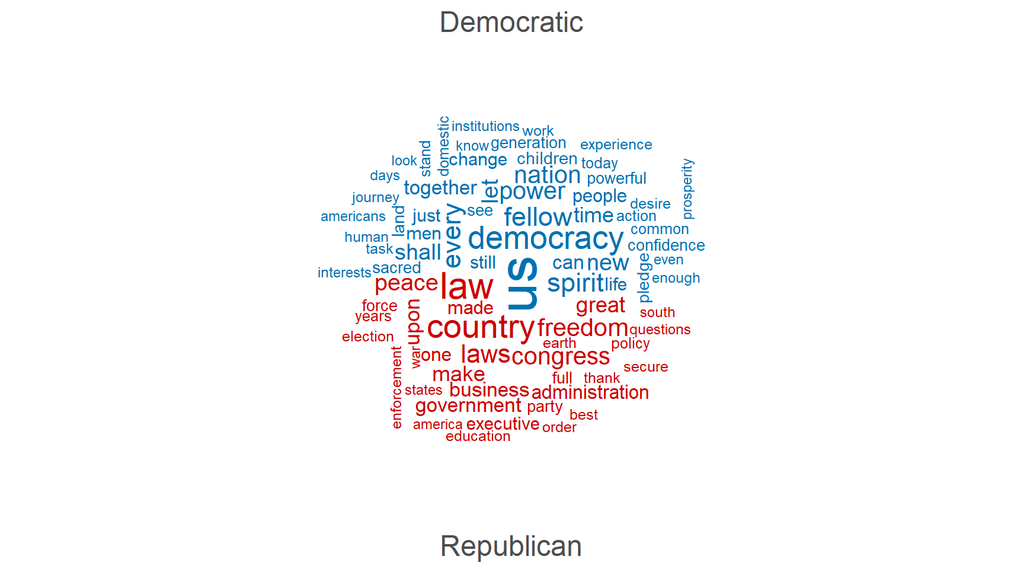

Figure 5: Comparison word cloud: Democratic vs Republican inaugural addresses. Size reflects frequency; colour and position reflect distinctiveness to each party.

```r
inaugural_dfm |>
  dfm_subset(Party %in% c("Democratic", "Republican")) |>
  dfm_group(groups = Party) |>
  dfm_trim(min_termfreq = 3) |>
  textplot_wordcloud(
    comparison = TRUE,
    max_words  = 80,
    color      = c("#0072B2", "#CC0000")
  )
```

The comparison word cloud is visually intuitive but analytically imprecise — it is a tool for exploration and communication, not inference. We use it here to generate hypotheses that more rigorous methods in later weeks can test properly.

## 8.5 Comparing the Two Ecosystems

Both packages are excellent and solve overlapping but distinct problems:

| Feature | tidytext | quanteda |
| --- | --- | --- |
| **Data structure** | Tidy tibble (one-token-per-row) | DFM (sparse matrix) |
| **Integrates with** | dplyr, ggplot2, tidymodels | quanteda.textmodels, stm, spacyr |
| **Best for** | Exploration, visualisation, joining metadata | Topic models, scaling, classification |
| **Corpus size** | Small–medium | Large corpora |
| **Learning curve** | Gentle (tidyverse idioms) | Moderate (new data structures) |
| **This course** | Weeks 1–2 (primary) | Weeks 3–4 (primary) |

The two are not mutually exclusive. A common workflow — one we follow throughout this course — is to use `tidytext` for exploration and preprocessing, then convert to a DFM for modelling:

```r
# Converting a tidy tibble back to a DFM when needed for modelling
tidy_inaugural |>
  count(doc_id, word) |>
  cast_dfm(doc_id, word, n)
```

```
Document-feature matrix of: 60 documents, 8,788 features (93.49% sparse) and 0 docvars.
                 features
docs              accomplished acknowledge acquit act actual actuate add
  1789-Washington            1           1      1   1      1       1   1
  1793-Washington            0           0      0   1      0       0   0
  1797-Adams                 0           1      0   0      0       0   1
  1801-Jefferson             0           0      0   0      0       0   0
  1805-Jefferson             0           0      0   3      0       0   1
  1809-Madison               0           0      0   0      0       0   0
                 features
docs              addition addressed administration
  1789-Washington        1         1              2
  1793-Washington        0         0              1
  1797-Adams             0         0              3
  1801-Jefferson         0         0              2
  1805-Jefferson         0         0              1
  1809-Madison           0         0              0
[ reached max_ndoc ... 54 more documents, reached max_nfeat ... 8,778 more features ]
```

`cast_dfm()` is the bridge between the two worlds: it takes a tidy word-count data frame and produces a quanteda DFM directly.

# 9 Discussion Questions

*5 minutes individual thinking · 10 minutes group discussion*

**Question 1 — What text data exists in your own research area?** Think about what you would want to measure from it. Is the text already collected, or would you need to create or gather a corpus? What would be the main practical and ethical obstacles?

**Question 2 — Pick a concept from your field. How would you operationalise it from text — and what could go wrong?** Examples: trust, polarisation, framing, social cohesion, inequality. Which NLP method would you use (dictionary, topic model, classifier)? What would a failure of validity look like in practice — and how would you detect it?

# 10 Take-Home Exercise

Complete before Week 2. Bring your output and interpretation to class.

**Exercise 1 — Change the grouping variable.** Re-run the tf-idf analysis grouping by individual president rather than era. Which presidents have the most distinctive vocabularies? Does this align with your prior knowledge of US political history?

```r
president_tfidf <- tidy_inaugural |>
  count(President, word, sort = TRUE) |>
  bind_tf_idf(word, President, n) |>
  arrange(desc(tf_idf))

# Find the 6 presidents with the most distinctive language overall
top_presidents <- president_tfidf |>
  group_by(President) |>
  summarise(max_tfidf = max(tf_idf)) |>
  slice_max(max_tfidf, n = 6) |>
  pull(President)

# Visualise — complete the ggplot pipeline
president_tfidf |>
  filter(President %in% top_presidents) |>
  group_by(President) |>
  slice_max(tf_idf, n = 8) |>
  ungroup() |>
  mutate(word = reorder_within(word, tf_idf, President)) |>
  ggplot(aes(x = word, y = tf_idf, fill = President)) +
  # --- add geom, coord_flip, facet_wrap, scale_x_reordered, theme ---
  identity()
```

**Exercise 2 — Narrow the time window.** Filter the corpus to post-1945 addresses only. Re-run tf-idf by era. Do the results change meaningfully compared to the full corpus? What does this tell you about how within-era variation can mask between-era patterns?

```r
tidy_postwar <- tidy_inaugural |>
  filter(Year >= 1945)

postwar_tfidf <- tidy_postwar |>
  count(era, word, sort = TRUE) |>
  bind_tf_idf(word, era, n) |>
  arrange(desc(tf_idf))

# --- add your visualisation ---
```

**Exercise 3 — Write your interpretation.** Write 3–4 sentences addressing: What do the most distinctive words per era reveal about how American political discourse has changed? What can you *not* conclude from this analysis, and why? What additional evidence would you need to make a causal claim about what drives shifts in presidential language?

# 11 What Comes Next

Today we covered the first rung of the method ladder: frequency, word counts, and tf-idf. We introduced the tidy text format and the quanteda DFM as the two dominant data structures for text analysis in R, and applied both to a long-running political speech corpus that spans over two centuries of American presidential rhetoric.

**Week 2 — Dictionary & Sentiment.** We apply pre-built sentiment lexicons (AFINN, Bing, NRC) to the inaugural addresses and build custom dictionaries. We also confront the validation question head-on: does a general-purpose sentiment lexicon capture political tone, or does it require domain-specific adaptation?

**Week 3 — Topic Modelling.** We introduce Latent Dirichlet Allocation (LDA) and the Structural Topic Model (STM), where topics vary with document-level covariates such as party, era, and year. Topic prevalence becomes an outcome variable in its own right.

**Week 4 — Classification & Beyond.** We train supervised classifiers using `tidymodels`, introduce word embeddings (word2vec), and take a first look at transformer-based language models.

# 12 References

- Silge, J. & Robinson, D. (2017). *Text Mining with R: A Tidy Approach*. O’Reilly Media. https://www.tidytextmining.com
- Benoit, K. et al. (2018). quanteda: An R package for the quantitative analysis of textual data. *Journal of Open Source Software*, 3(30), 774.
- Laver, M., Benoit, K. & Garry, J. (2003). Extracting policy positions from political texts using words as data. *American Political Science Review*, 97(2), 311–331.
- Heidenreich, T. et al. (2019). Media framing dynamics of the ‘European refugee crisis’. *Journal of Refugee Studies*, 32(S1), i172–i182.

*NLP for Social Scientists · Week 1 · Corvinus University of Budapest 2025/2026*